# Getting Started with spatialAtomizeR

Yunzhe Qian (Bella), Principal Investigators: Dr. Nancy Krieger and Dr. Rachel Nethery

2026-03-24

## Overview

`spatialAtomizeR` implements atom-based Bayesian regression methods (ABRM) for spatial data with misaligned grids. This vignette demonstrates the basic workflow for analyzing misaligned spatial data using both simulated and real-world examples.

## Installation

```r
# Install from CRAN
install.packages("spatialAtomizeR")

# Or install development version from GitHub
# devtools::install_github("bellayqian/spatialAtomizeR")
```

## Load Required Packages

```r
library(spatialAtomizeR)
```

# Example 1: Simulated Data

This example demonstrates the complete workflow using simulated data.

## Step 1: Simulate Misaligned Data

```r
sim_data <- simulate_misaligned_data(
  seed = 42,

  # Distribution specifications for covariates
  dist_covariates_x = c('normal', 'poisson', 'binomial'),
  dist_covariates_y = c('normal', 'poisson', 'binomial'),
  dist_y = 'poisson',  # Outcome distribution

  # Intercepts for data generation (REQUIRED)
  x_intercepts = c(4, -1, -1),      # One per X covariate
  y_intercepts = c(4, -1, -1),      # One per Y covariate
  beta0_y = -1,                     # Outcome model intercept

  # Spatial correlation parameters
  x_correlation = 0.5,  # Correlation between X covariates
  y_correlation = 0.5,  # Correlation between Y covariates

  # True effect sizes for outcome model
  beta_x = c(-0.03, 0.1, -0.2),    # Effects of X covariates
  beta_y = c(0.03, -0.1, 0.2)      # Effects of Y covariates
)
```

The simulated data object contains: - `gridx`: X-grid spatial features with covariates - `gridy`: Y-grid spatial features with covariates and outcome - `atoms`: Atom-level spatial features (intersection of grids) - `true_params`: True parameter values used in simulation

## Step 2: Examine Simulated Data

The `simulate_misaligned_data` function returns an object of class `misaligned_data` with useful S3 methods:

```r
# Check the class
class(sim_data)
```

```
#> [1] "misaligned_data"
```

```r
# Print method shows basic information
print(sim_data)
```

```
#> Simulated Misaligned Spatial Data
#> ==================================
#> Y-grid cells: 25
#> X-grid cells: 30
#> Atoms: 35
#> Number of X covariates: 3
#> Number of Y covariates: 3
#> True parameters available
```

```r
# Summary method shows more details
summary(sim_data)
```

```
#> Simulated Misaligned Spatial Data
#> ==================================
#> Y-grid cells: 25
#> X-grid cells: 30
#> Atoms: 35
#> Number of X covariates: 3
#> Number of Y covariates: 3
#> True parameters available
#> True beta_x: -0.03, 0.1, -0.2
#> True beta_y: 0.03, -0.1, 0.2
```

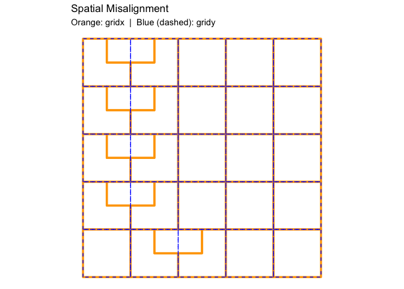

```r
# Default: overlay both grids to visualise misalignment
plot(sim_data)
```

## Step 3: Get ABRM Model Code

Retrieve the pre-compiled NIMBLE model specification:

```r
model_code <- get_abrm_model()
```

## Step 4: Run ABRM Analysis

Fit the ABRM model. You must specify which covariates follow which distributions by providing their indices:

```r
abrm_results <- run_abrm(
  gridx = sim_data$gridx,
  gridy = sim_data$gridy,
  atoms = sim_data$atoms,
  model_code = model_code,
  true_params = sim_data$true_params,  # Optional: for validation

  # Map distribution indices to positions in dist_covariates_x/y
  norm_idx_x = 1,   # 'normal' is 1st in dist_covariates_x
  pois_idx_x = 2,   # 'poisson' is 2nd
  binom_idx_x = 3,  # 'binomial' is 3rd
  norm_idx_y = 1,   # Same for Y covariates
  pois_idx_y = 2,
  binom_idx_y = 3,

  # Outcome distribution: 1=normal, 2=poisson, 3=binomial
  dist_y = 2,

  # MCMC parameters
  niter = 50000,    # Total iterations per chain
  nburnin = 30000,  # Burn-in iterations
  nchains = 2,      # Number of chains
  seed = 123,
  compute_waic = TRUE
)
```

## Step 5: Examine ABRM Results

The `run_abrm` function returns an object of class `abrm` with S3 methods:

```r
# Check the class
class(abrm_results)
```

```
#> [1] "abrm"
```

```r
# Print method shows summary statistics
print(abrm_results)
```

```
#>
#> ABRM Model Results
#> ==================
#> Parameters estimated: 7
#> Mean absolute bias:  0.2402
#> Coverage rate:       100 %
#>
#> Use summary() for the full parameter table.
```

```r
# Summary method shows detailed parameter estimates
summary(abrm_results)
```

```
#> ABRM Model Summary
#> ==================
#> Parameters estimated: 7
#> Mean absolute bias:  0.2402
#> Coverage rate:  100 %
#>
#>       variable estimated_beta std_error ci_lower ci_upper true_beta     bias
#>      intercept       -0.54060    1.3053 -2.70688   1.8998     -1.00  0.45940
#>  covariate_x_1        0.06764    0.1474 -0.21282   0.3599     -0.03  0.09764
#>  covariate_x_2        0.24491    0.4059 -0.58058   1.0313      0.10  0.14491
#>  covariate_x_3       -0.68932    0.8488 -2.29887   1.0312     -0.20 -0.48932
#>  covariate_y_1        0.20855    0.1427 -0.07177   0.4874      0.03  0.17855
#>  covariate_y_2        0.04571    0.6241 -1.17400   1.2215     -0.10  0.14571
#>  covariate_y_3        0.03415    0.7763 -1.39218   1.5496      0.20 -0.16585
#>  relative_bias within_ci
#>         -45.94      TRUE
#>        -325.47      TRUE
#>         144.91      TRUE
#>         244.66      TRUE
#>         595.17      TRUE
#>        -145.71      TRUE
#>         -82.93      TRUE
```

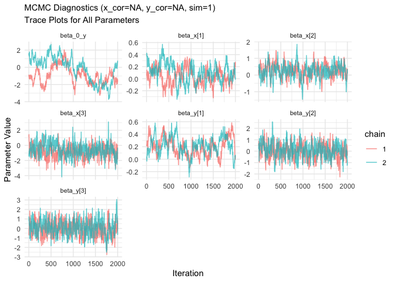

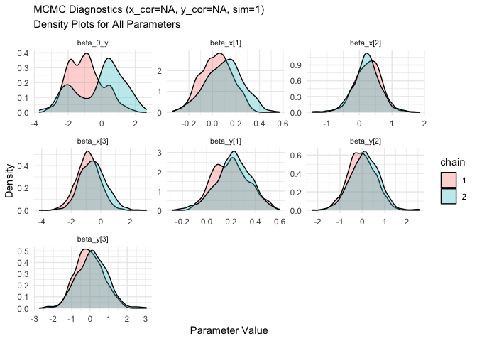

```r
# Plot method shows MCMC diagnostics (if available)
plot(abrm_results)
```

## Step 6: More Tests

### Access vairance-covariance matrices from the MCMC posterior sample

```r
# Get variance-covariance matrices
vcov(abrm_results)
```

```
#>
#> Variance-Covariance Matrices for ABRM Model
#> ============================================
#>
#> Intercept Variance:
#>   beta_0_y: 1.703773
#> X-Grid Coefficients Variance-Covariance Matrix:
#>   Dimensions: 3 x 3
#>               covariate_x_1 covariate_x_2 covariate_x_3
#> covariate_x_1      0.021714     -0.014287      0.036561
#> covariate_x_2     -0.014287      0.164777     -0.069159
#> covariate_x_3      0.036561     -0.069159      0.720543
#>
#> Y-Grid Coefficients Variance-Covariance Matrix:
#>   Dimensions: 3 x 3
#>               covariate_y_1 covariate_y_2 covariate_y_3
#> covariate_y_1      0.020363     -0.011530     -0.020613
#> covariate_y_2     -0.011530      0.389514     -0.084022
#> covariate_y_3     -0.020613     -0.084022      0.602699
#>
#> Use vcov_object$vcov_beta_x, vcov_object$vcov_beta_y, etc. to access matrices
```

```r
# Test coef()
coef(abrm_results)
```

```
#>      beta_0_y covariate_x_1 covariate_x_2 covariate_x_3 covariate_y_1
#>   -0.54060357    0.06764204    0.24491310   -0.68931577    0.20855084
#> covariate_y_2 covariate_y_3
#>    0.04571204    0.03414577
```

```r
# Test confint()
confint(abrm_results)
```

```
#>                  CI.Lower  CI.Upper
#> intercept     -2.70688305 1.8998461
#> covariate_x_1 -0.21281539 0.3598648
#> covariate_x_2 -0.58057793 1.0312572
#> covariate_x_3 -2.29886717 1.0311990
#> covariate_y_1 -0.07176605 0.4874385
#> covariate_y_2 -1.17400383 1.2215393
#> covariate_y_3 -1.39217558 1.5496064
```

```r
# Test parm subsetting
confint(abrm_results, parm = "covariate_x_1")
```

```
#>                 CI.Lower  CI.Upper
#> covariate_x_1 -0.2128154 0.3598648
```

```r
# Test fitted()
fitted(abrm_results)
```

```
#>    y_grid_id observed  fitted residual
#> 1          3       31 30.2001   0.7999
#> 2          4       18 18.8310  -0.8310
#> 3          5       34 33.5033   0.4967
#> 4          8       11 12.7122  -1.7122
#> 5          9       34 32.6033   1.3967
#> 6         10       42 38.8583   3.1417
#> 7         13       22 22.9119  -0.9119
#> 8         14       16 17.2410  -1.2410
#> 9         15       10 11.9866  -1.9866
#> 10        18       56 53.6539   2.3461
#> 11        19       36 33.7592   2.2408
#> 12        20       17 16.9202   0.0798
#> 13        21       42 39.5999   2.4001
#> 14        24       18 17.4957   0.5043
#> 15        25       35 35.0852  -0.0852
#> 16         1       19 46.1751 -27.1751
#> 17         2       39 37.5169   1.4831
#> 18         6       43 62.4962 -19.4962
#> 19         7       68 52.0277  15.9723
#> 20        11       38 41.1438  -3.1438
#> 21        12       63 47.8334  15.1666
#> 22        16       40 74.6093 -34.6093
#> 23        17       56 60.5217  -4.5217
#> 24        22       67 95.8024 -28.8024
#> 25        23       50 55.6886  -5.6886
```

```r
# waic_abrm Objects
w <- waic(abrm_results)
print(w)          # shows WAIC, lppd, pWAIC, n_params
```

```
#> WAIC for ABRM
#> =============
#> WAIC   : 1071.471
#> lppd   : -470.611  (log pointwise predictive density)
#> pWAIC  : 65.125  (effective number of parameters)
#>
#> Note: lower WAIC indicates better predictive fit.
#>       Compare only models fitted on identical data.
```

```r
w$waic            # the raw scalar if you need it for comparison
```

```
#> [1] 1071.471
```

# Example 2: Real Data - Utah Counties and School Districts

This example demonstrates using real spatial data from Utah, matching the analysis in the manuscript.

## Load Required Packages for Spatial Data

```r
library(tigris)    # For US Census shapefiles
library(sf)        # Spatial features
library(sp)        # Spatial objects
library(spdep)     # Spatial dependence
library(raster)    # Spatial data manipulation
library(dplyr)     # Data manipulation
library(ggplot2)   # Plotting
```

## Step 1: Load Utah Shapefiles

```r
set.seed(500)

# Load Utah counties (Y-grid)
cnty <- counties(state = 'UT')
```

[output not shown]

```r
gridy <- cnty %>%
  rename(ID = GEOID) %>%
  mutate(ID = as.numeric(ID))  # ID must be numeric

# Load Utah school districts (X-grid)
scd <- school_districts(state = 'UT')
```

[output not shown]

```r
gridx <- scd %>%
  rename(ID = GEOID) %>%
  mutate(ID = as.numeric(ID))
```

## Step 2: Visualize Spatial Misalignment

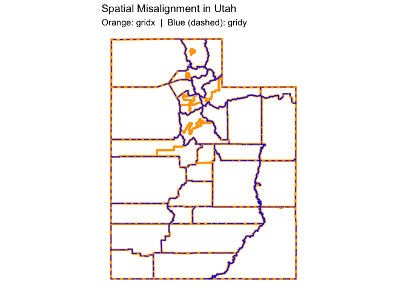

```r
# Bundle grids into a misaligned_data object
utah_mis <- structure(
  list(gridy = gridy, gridx = gridx),
  class = "misaligned_data"
)

# Default overlay plot
plot(utah_mis, color_x = "orange", color_y = "blue", title   = "Spatial Misalignment in Utah")
```

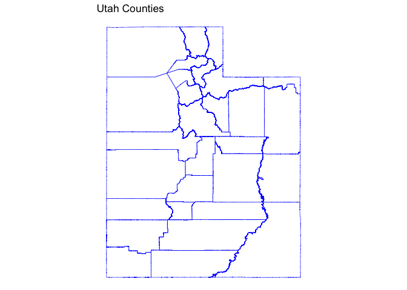

```r
# You can also inspect each grid separately
plot(utah_mis, which = "gridy", title = "Utah Counties")
```

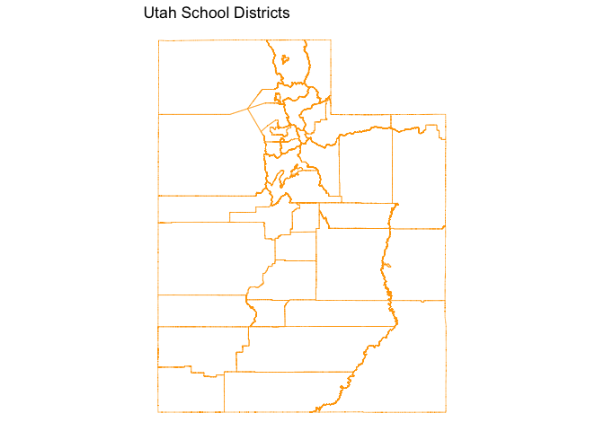

```r
plot(utah_mis, which = "gridx", title = "Utah School Districts")
```

## Step 3: Create Atoms by Intersecting Grids

```r
# Intersect the two grids to create atoms
atoms <- raster::intersect(as(gridy, 'Spatial'), as(gridx, 'Spatial'))
atoms <- sf::st_as_sf(atoms)

# Rename ID variables — column names vary by sf version:
# Note: raster::intersect() + sf::st_as_sf() produces "ID"/"ID.1" on older sf
# and "ID_1"/"ID_2" on newer sf (>= 1.0). This grep-based approach handles both.
id_cols <- grep("^ID", names(atoms), value = TRUE)
names(atoms)[names(atoms) == id_cols[1]] <- "ID_y"
names(atoms)[names(atoms) == id_cols[2]] <- "ID_x"
```

## Step 4: Add Atom-Level Population Counts

ABRM requires population counts at the atom level. Here we use LandScan gridded population data:

```r
# NOTE: You must download LandScan data separately
# Available at: https://landscan.ornl.gov/
# This example assumes the file is in your working directory

pop_raster <- raster("landscan-global-2022.tif")

# Extract population for each atom
pop_atoms <- raster::extract(
  pop_raster,
  st_transform(atoms, crs(pop_raster)),
  fun = sum,
  na.rm = TRUE
)

atoms$population <- pop_atoms
```

## Step 5: Generate Semi-Synthetic Outcome and Covariates

For demonstration, we generate synthetic outcome and covariate data at the atom level:

```r
# Create atom-level spatial adjacency matrix
W_a <- nb2mat(
  poly2nb(as(atoms, "Spatial"), queen = TRUE),
  style = "B",
  zero.policy = TRUE
)

# Generate spatial random effects
atoms <- atoms %>%
  mutate(
    re_x = gen_correlated_spat(W = W_a, n_vars = 1, correlation = 1, rho = 0.8),
    re_z = gen_correlated_spat(W = W_a, n_vars = 1, correlation = 1, rho = 0.8),
    re_y = gen_correlated_spat(W = W_a, n_vars = 1, correlation = 1, rho = 0.8)
  )

# Generate atom-level covariates and outcome
atoms <- atoms %>%
  mutate(
    # X-grid covariate (Poisson)
    covariate_x_1 = rpois(
      n = nrow(atoms),
      lambda = population * exp(-1 + re_x)
    ),
    # Y-grid covariate (Normal)
    covariate_y_1 = rnorm(
      n = nrow(atoms),
      mean = population * (3 + re_z),
      sd = 1 * population
    )
  ) %>%
  mutate(
    # Outcome (Poisson)
    y = rpois(
      n = nrow(atoms),
      lambda = population * exp(
        -5 +
        1 * (covariate_x_1 / population) -
        0.3 * (covariate_y_1 / population) +
        re_y
      )
    )
  )
```

## Step 6: Aggregate to Observed Grids

In reality, we only observe aggregated data at the grid level, not at atoms:

```r
# Aggregate X covariates to X-grid
gridx[["covariate_x_1"]] <- sapply(gridx$ID, function(j) {
  atom_indices <- which(atoms$ID_x == j)
  sum(atoms[["covariate_x_1"]][atom_indices])
})

# Aggregate Y covariates to Y-grid
gridy[["covariate_y_1"]] <- sapply(gridy$ID, function(j) {
  atom_indices <- which(atoms$ID_y == j)
  sum(atoms[["covariate_y_1"]][atom_indices])
})

# Aggregate outcome to Y-grid
gridy$y <- sapply(gridy$ID, function(j) {
  atom_indices <- which(atoms$ID_y == j)
  sum(atoms$y[atom_indices])
})
```

## Step 7: Run ABRM on Real Data

```r
model_code <- get_abrm_model()

mcmc_results <- run_abrm(
  gridx = gridx,
  gridy = gridy,
  atoms = atoms,
  model_code = model_code,

  # Specify covariate distributions
  pois_idx_x = 1,  # X covariate is Poisson
  norm_idx_y = 1,  # Y covariate is Normal
  dist_y = 2,      # Outcome is Poisson

  # MCMC settings (increase for real analysis)
  niter = 300000,
  nburnin = 200000,
  nchains = 2,
  seed = 123,
  compute_waic = TRUE
)
```

## Step 8: Examine Real Data Results

```r
# View results from the Utah model fit
summary(mcmc_results)

# Get variance-covariance matrices
vcov(mcmc_results)

# Coefficient estimates
coef(mcmc_results)

# 95% confidence intervals
confint(mcmc_results)

# WAIC
w <- waic(mcmc_results)
print(w)
```

# Understanding Distribution Indices

When you specify covariates, the indices correspond to their positions:

```r
dist_covariates_x = c('normal', 'poisson', 'binomial')
#                       ^1        ^2         ^3

# So you would specify:
norm_idx_x = 1    # First position
pois_idx_x = 2    # Second position
binom_idx_x = 3   # Third position
```

## Distribution Type Codes

| Code | Distribution | String | Use Case |
| --- | --- | --- | --- |
| 1 | Normal | ‘normal’ | Continuous data |
| 2 | Poisson | ‘poisson’ | Count/rate data |
| 3 | Binomial | ‘binomial’ | Proportion/binary data |

## Getting Help

- Function documentation: `?simulate_misaligned_data`, `?run_abrm`
- Report issues: https://github.com/bellayqian/spatialAtomizeR/issues
- Package help: `?spatialAtomizeR`

# Citation

```r
citation("spatialAtomizeR")
```

**Reference:** Qian, Y., Johnson, N., Krieger, N., & Nethery, R.C. (2026). spatialAtomizeR: Atom-Based Regression Models for Spatially Misaligned Data in R. R package version 0.2.7.